# Who Owns Your Research: A Survey

Jan Vitek

March 12, 2015

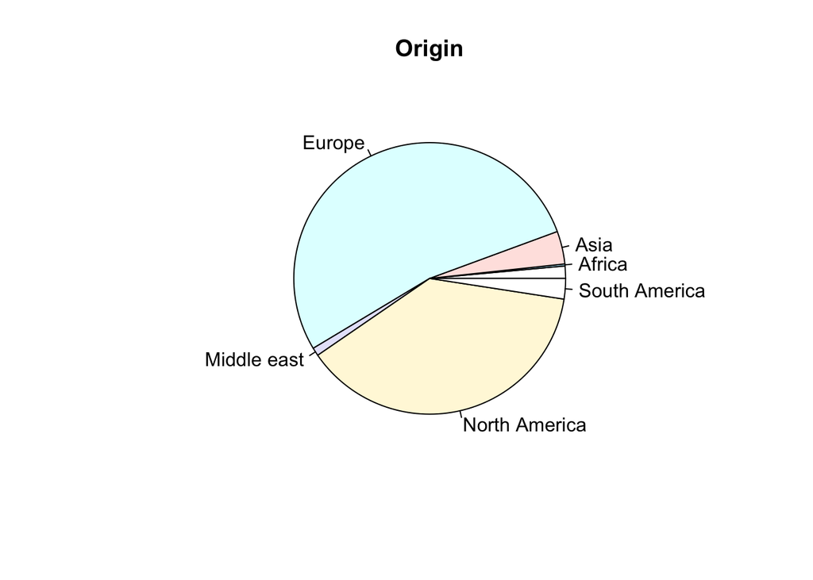

The respondent are divided between academia (79%) and industry (19%).

The relative seniority of respondents as measured by the time from their first publication is summarized in the following pie chart.

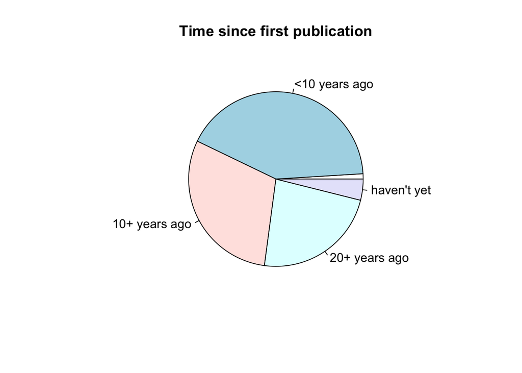

We use the following shortcuts: **USA** to mean responses from North America, **EU** for responses that come from Europe, **Senior** for respondent who have published their first paper more than 20 years ago, **Middle** for those who have first published ten years ago, and **Junior** for authors who have published less than 10 years ago. **ACM** will denote respondent who are members of the ACM.

**Observations:** *The survey was publicized by email to SIGPLAN and SIGPOPS members, and then virally through social media and personnal connections. One possible explanation for the higher response rate from Europe is that the issues of open access are considered more important there.*

# Open Access is a Moral Imperative

On the question wether open access (OA) is a “moral imperative”, 73% of respondents agreed. The other responses where a “desirable features” and “not essential”.

The proportion of respondents who believe that adopting OA is a necessity depends on origin and seniority. The following table highlights the differences. Respondents outside of the **USA** were slightly more favorable to OA (75%). Seniority seemed to play a big role in attitudes, with more junior respondents having stronger feelings (81%). The most striking difference is between **Senior USA Academics** and **Junior USA Academics** the former favoring OA at 53% and the latter at a whopping 87%.

In all groups the majority views open access as a moral imperative.

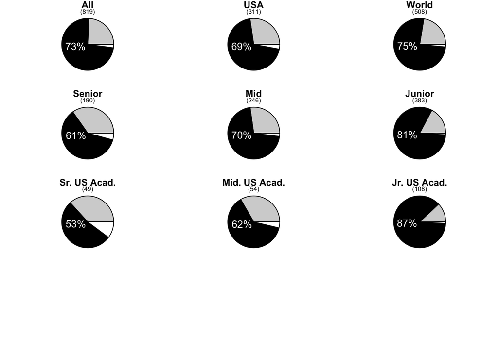

**Observation:** *There seems to be little question that OA is a shared value for the community. The survey argued in favor of “Gold OA” because SIGPLAN feels that it is important that all paper be accessible. While “Green OA” allows authors to share their papers, it relies on authors to do so, and to make sure that OA links remain accessible. This can’t be guaranteed and won’t be true for older work of authors who do not have a web presence. The fact that junior authors are strongly in favor of OA is encouraging for going forward.*

The question of how to fund OA divides respondents: 27% are in favor of author processing charges while 41% argue for increased conference registrations.

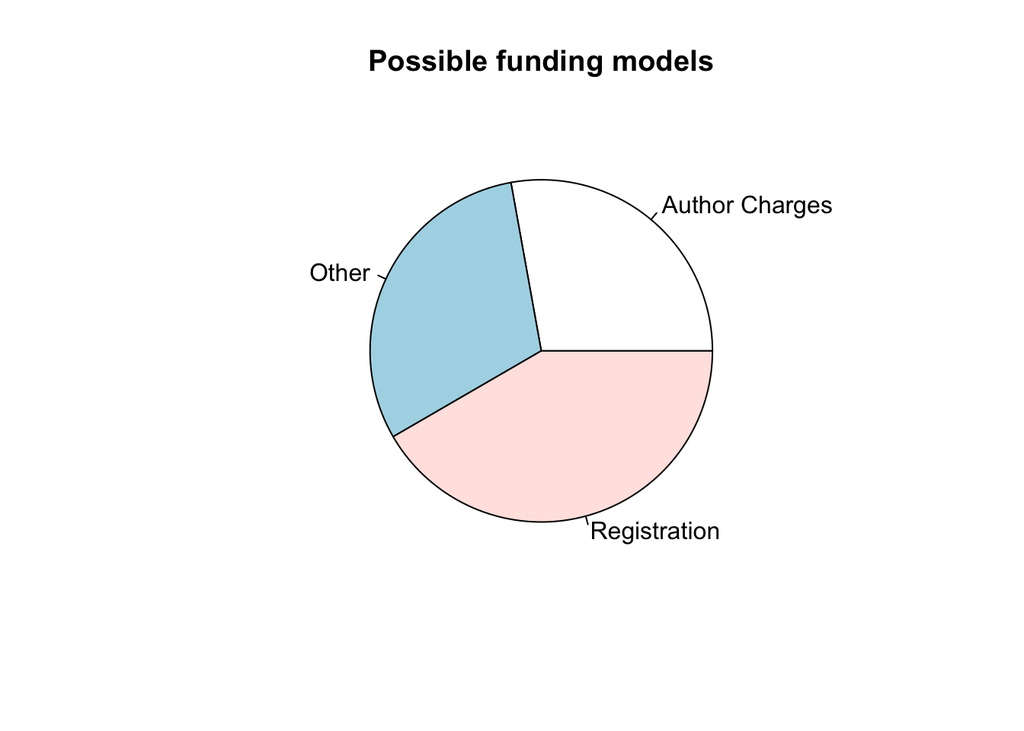

The remaining suggestions for funding OA are listed next. A number of comments suggest that a Green OA model shoud be considered. Other suggest models based on voluntary donnations similar to Wikipedia, on governmental and industry support, by increased ACM membership fees. Several comments point to arXiv as an example to follow. Lastly, some suggest cutting ACM’s expenses.

**Observations:** *It is our belief that whichever model is chosen, it is crucial to prevent cases where authors would be priced out of publishing. This can be achieved by setting the price of OA to be low enough and ensuring that exemption be available for authors unable to pay.*

In the case an author processing charge was selected, how much would be a reasonable price (in USD) for a paper? The majority of respondents, 63% to be precise, is willing to pay no more than $100 per paper. An additional 27% is willing to pay $200. The following pie chart breaks the price down.

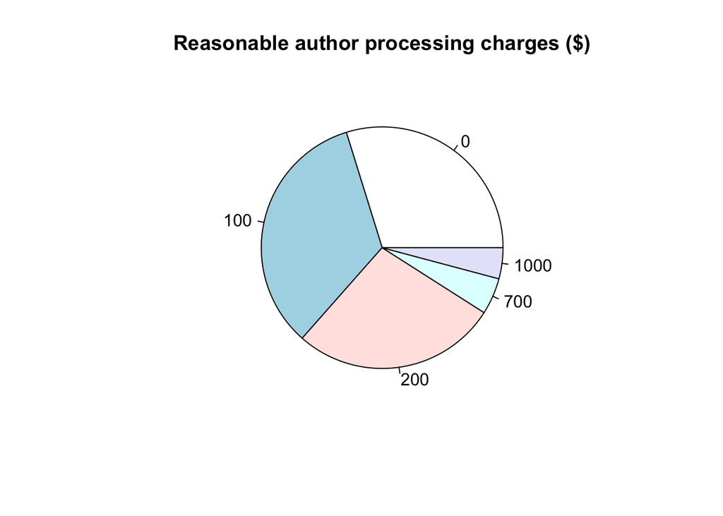

**Observation:** *A commercial publisher has offered to create a journal at $200 per paper. If a commercial publisher can make a profit at that price point, it stands to reason that ACM should be able to match that price.*

The issue of copyrights is fairly clear cut with 71% in favor of leaving copyrights with the authors.

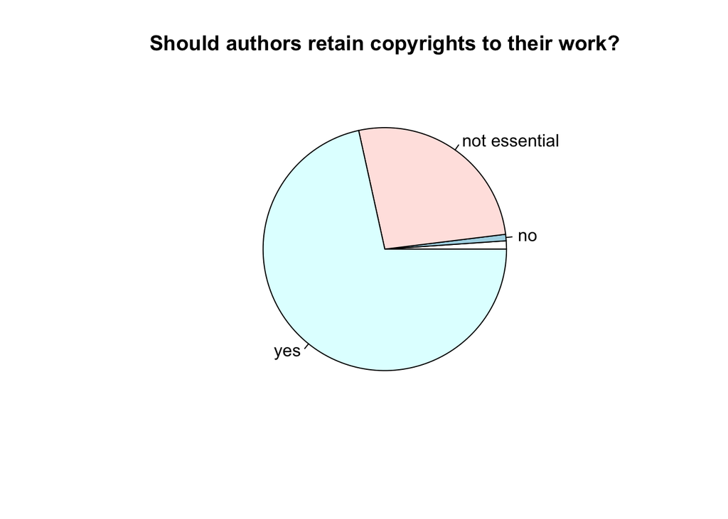

The last question was wether to look for another publisher if an open access option was not available within the ACM by 2017: 71% of respondents were in favor.

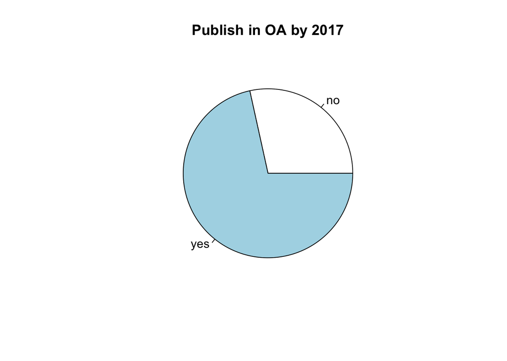

Looking closer reveals some interesting distinctions. The majority ACM members are in favor but sentiments are stronger in Europe.

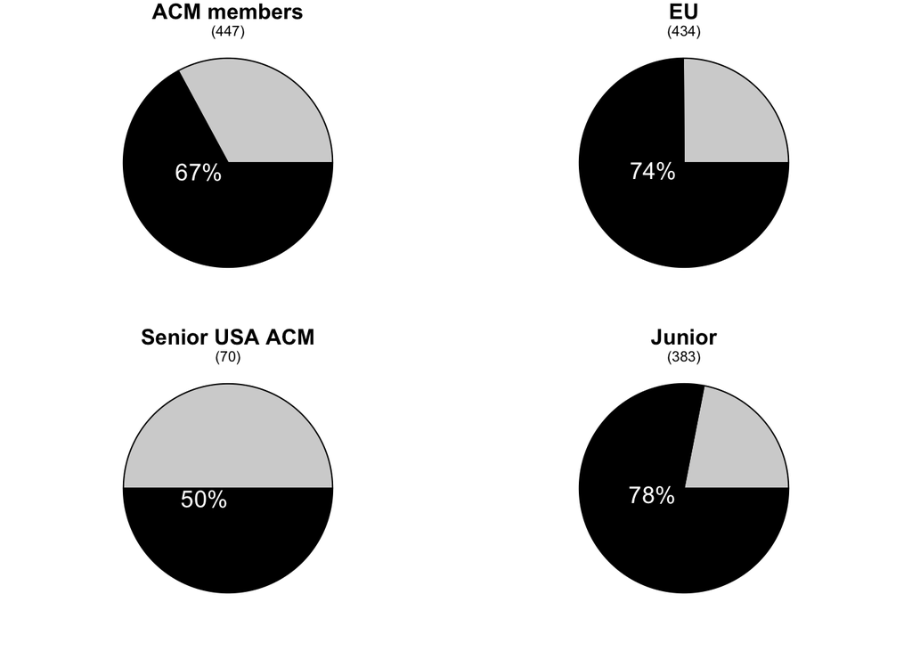

**Observation:** *The ECOOP conference was able to switch to an open access publisher that leaves copyright to authors within two months. Two years should be feasible, or at least there should be a clear plan for the transition.*

# Visions of ACM

The respondent provided comments about what they believed the ACM’s role should be. These comments show high levels of frustration with the organization and a disconnect between how the ACM views itself and what its members want it to be.

# The Place of Journals

**Observation:** *Conferences have a natural means of raising money: they can ask for industrial sponsorship and they charge their attendees registration fees. It is thus conceivable that conferences may be self sufficient. Journals, on the other hand, don’t have a clear funding model. It is unlikely that subscriptions would be sufficient to cover their costs. The question is thus what is their place in an OA world?*

When asked where important results appear 77% of respondents indicate that important results are first published in conferences.

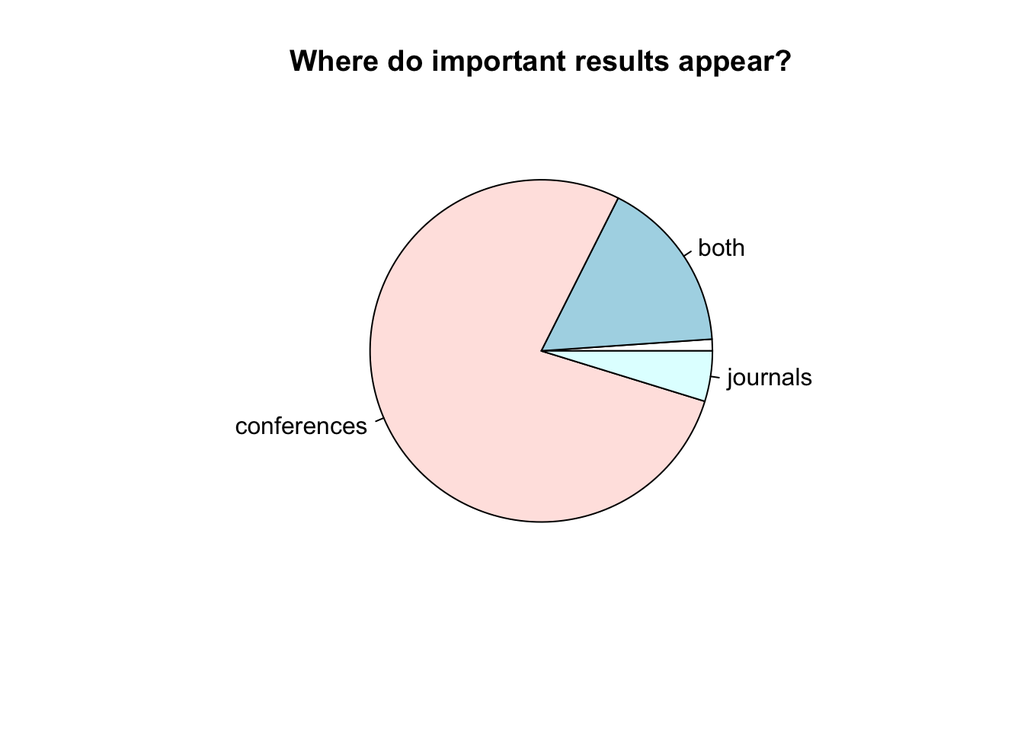

**Observation:** *In this respect CS seems quite different from other scientific disciplines. The selectivity, quality of reviews, and even length of CS conference papers are on par with what other disciplines would call journal articles.*

When asked wether they have published at least one paper in a journal in three years, 36% answer that they did not.

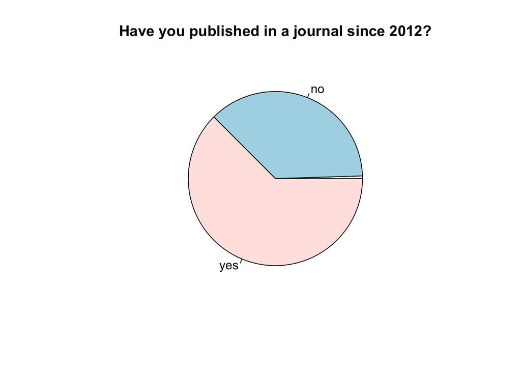

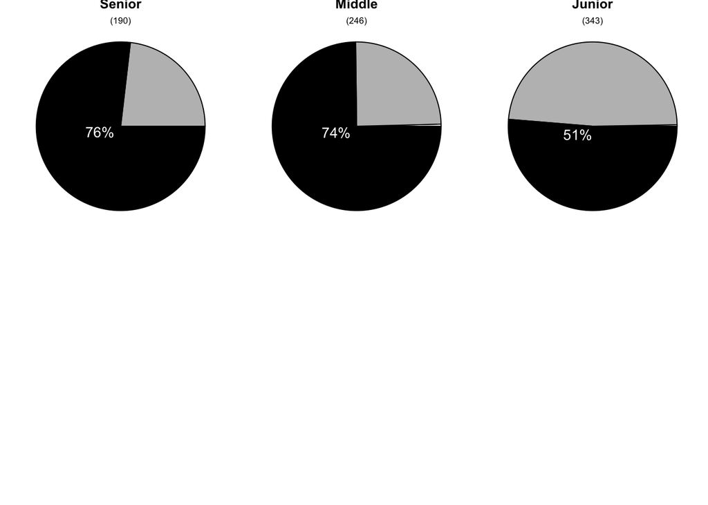

**Observation:** *The fact that many respondent do not publish regularly in journals is not sufficient to conclude that journals are not relevant, but it does at least suggest that they are not essential to a career in CS.*

In fact, 15% of the respondent have not even read a single journal paper in 2014.

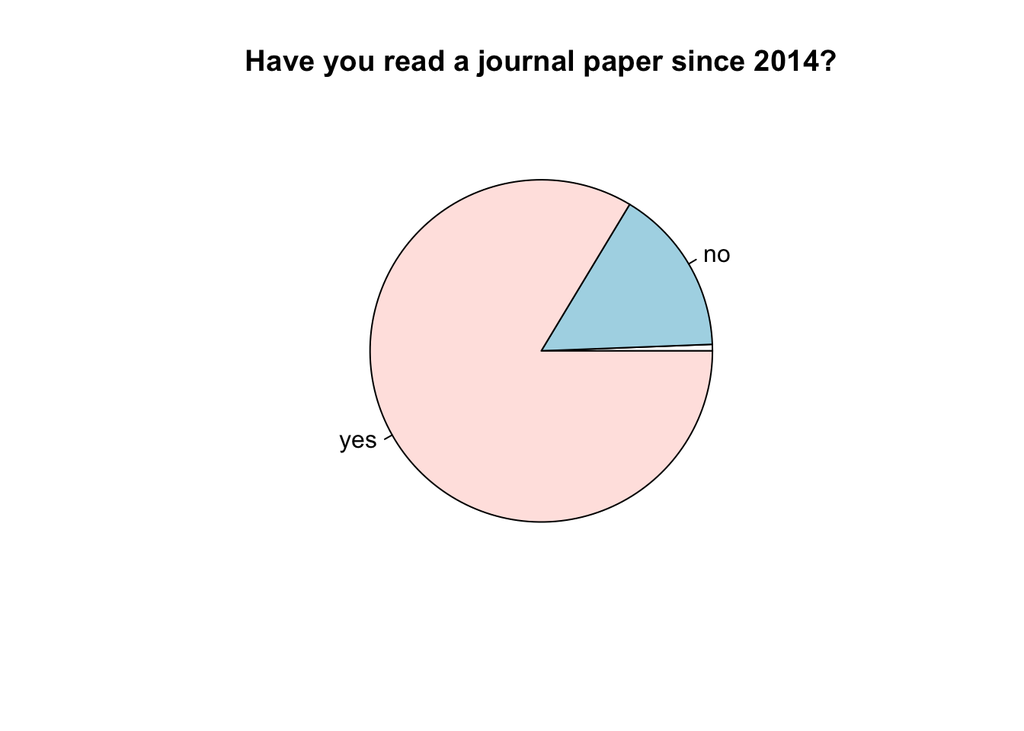

It is interesting to observe that while 51% of **Junior** authors have published a journal paper in the last three year, the chances that they will read a journal paper are no signifciantly different from other age groups.

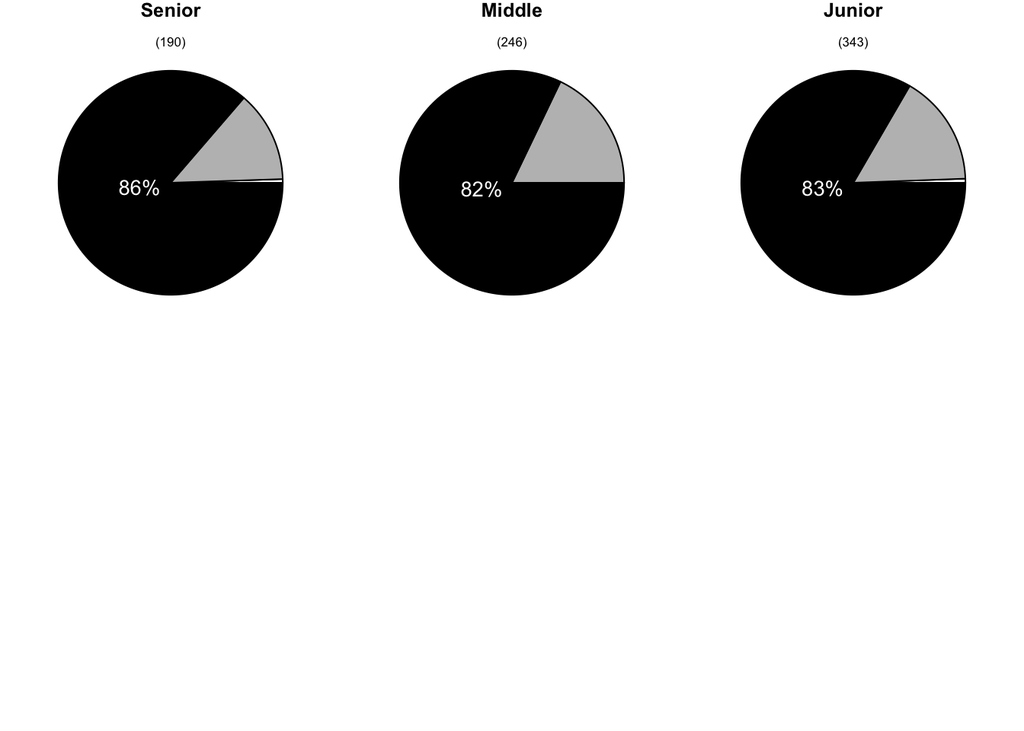

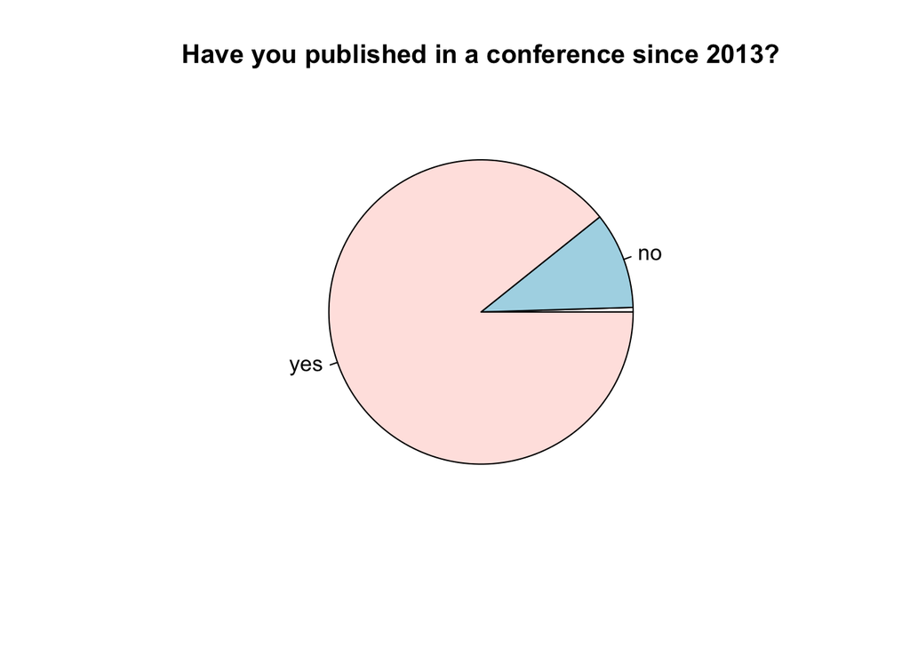

These numbers are remarkable stable accross age groups.

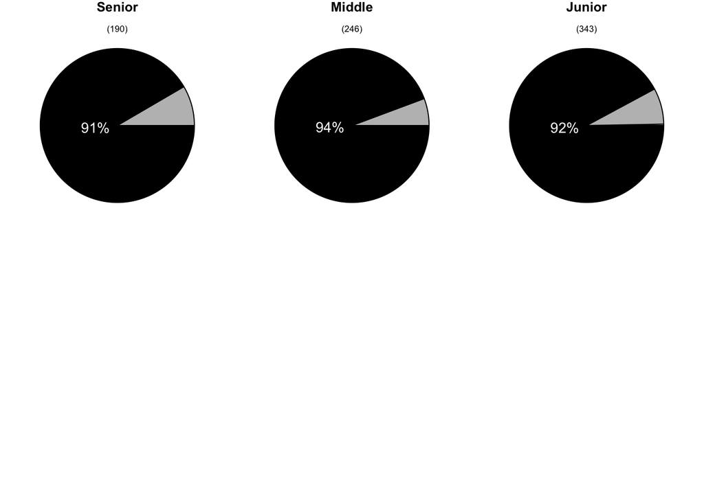

Considering that most authors do not believe that journals are where important results appear, why do they publish in journal? The following pie chart gives the main reasons: journals are favored because they allow long form results and because they publish completed research. It is also the case that respondent felt that their employer expects them to publish in journals.

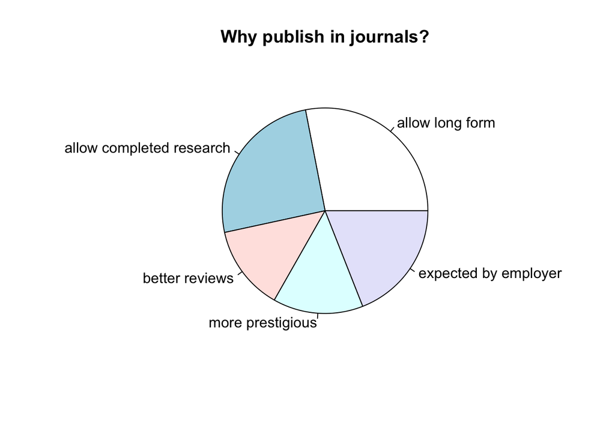

If we further focus on European respondents who are authors of journal papers we find that 50% of senior authors and 42% of junior authors believe they have to publish journal papers for career reasons.

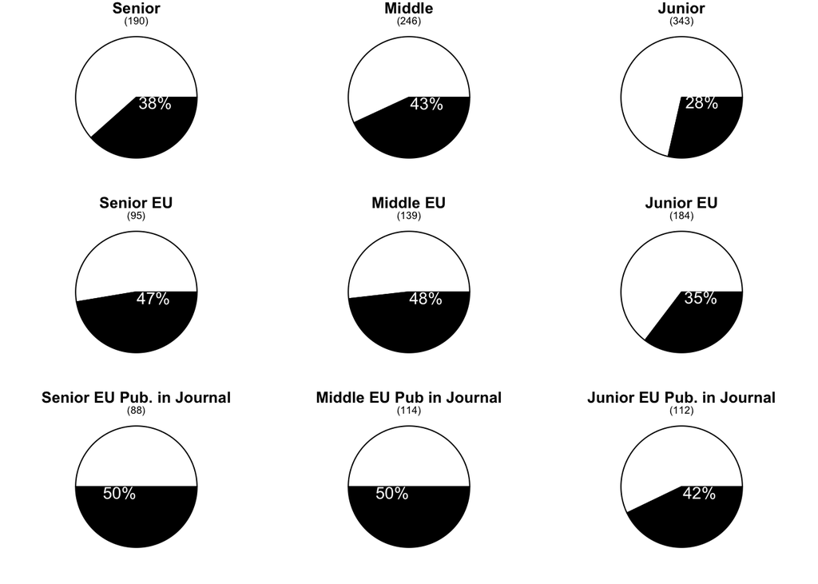

**Observation:** *While some have claimed that their employer has been educated to treat journals and conferences as equally valuable contributions. This seems to be less true in Europe. The fact that senior European authors, who know the requirements of tenure, believe so strongly that journals are needed for a succsessful career suggests that there is still a bias towards journal publications.*

73% of the respondent are in favor of publishing some of out conferences as special issues of journals.

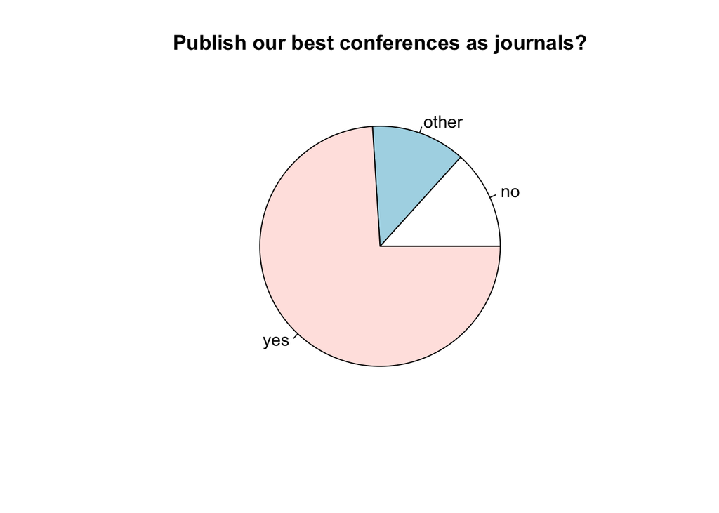

**Observations:** *SIGPLAN proposed to the ACM to publish the proceedings of the PLDI conference as a special issue of the TOPLAS. The proposal includes a beefed up reviewing model and the assurance that long version of PLDI papers can be submitted to another journal (even TOPLAS).*

# State of the DL

The ACM Digital Library splits respondents approximately as many feel that it makes it easy to find articles.

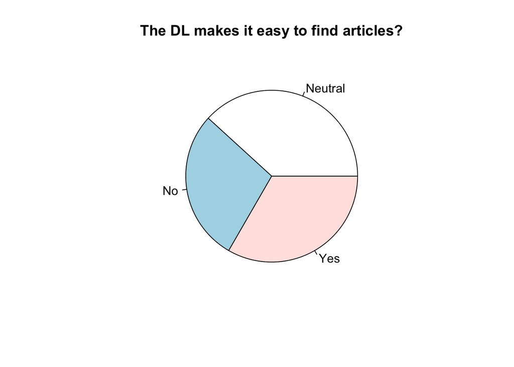

The opinions are similarly split as to whether the search facility that is part of the DL should be replaced by a commercial search engine.

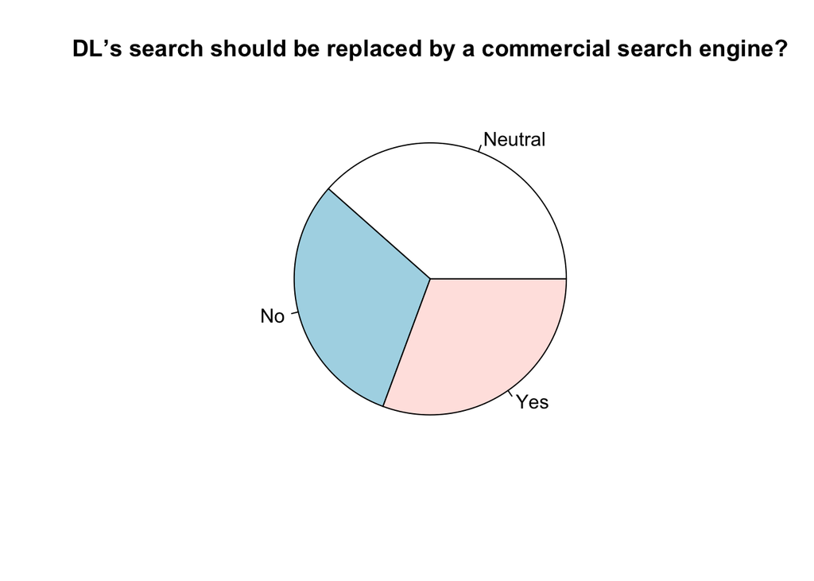

More respondents are in favor of using a system such as arXiv to archive the ACM’s paper rather than maintaining a dedicated one.

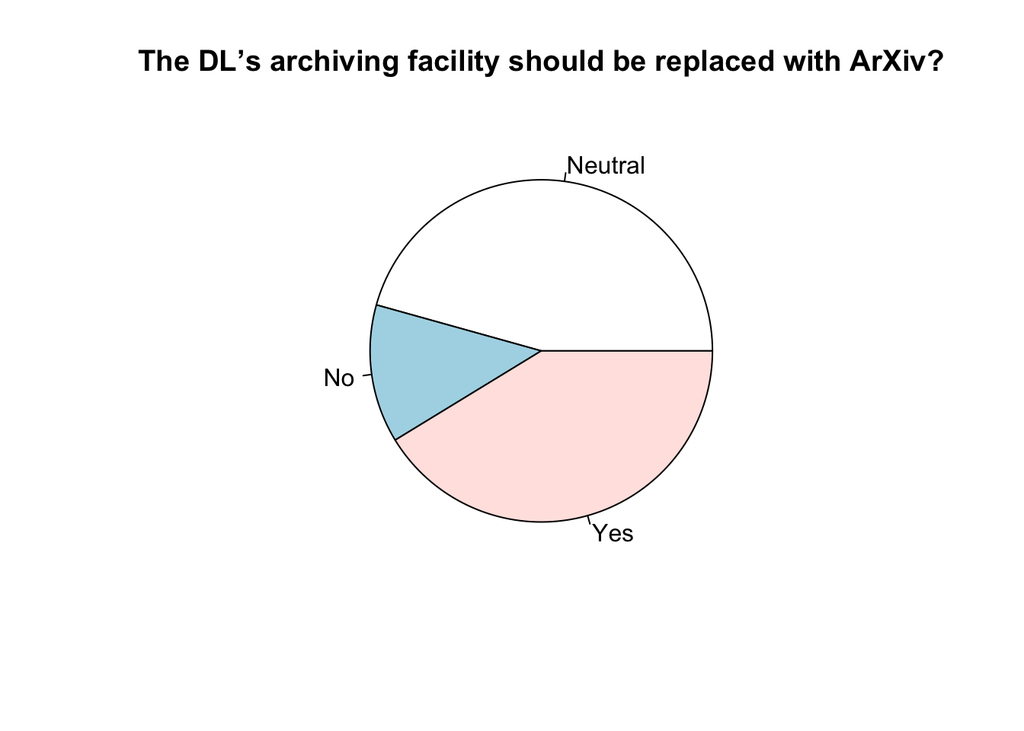

The textual comments suggest quite some frustration with the DL, it’s functionality and the fact that it is behind a paywall.

# ACM’s role Comments

```
##   [1] Supporting conferences
##   [2] The Good Works are important.  That's not to say there isn't bloat in ACM, but there is no other organization that maintains these important activities.
##   [3] An archive
##   [4] Good question... I do not real understand what ACM is for... Most of the work e.g., to set up conferences is done by benevolents
##   [5] To bring the computing community together.\n
##   [6] To make things cost more.  They don't seem to actually do anything else -- you can publish without them and organize conferences without them.
##   [7] To support computer science research and to advocate for computer scientists in society at large. Part of the latter role involves providing access to the actual research.
##   [8] Someone who is responsible for verification and providing trust that the paper is both of high-quality & authentic (results are not fraudulent).
##   [9] Advancing the field of computer science.
##  [10] advertise CS
##  [11] Sanctioning conferences and journals to employers
##  [12] (1) maintain digital library, (2) back SIG conferences, (3) fund Turing award.
##  [13] Roles should be:\nTo create a centralized platform for scientific material which is freely accessible to anyone.\n\nUnfortunately, roles seem to be:\nTo create a centralized platform for scientific material so that it can charge people who want to access the material (of course, not paying …
##  [14] It ought to be a scholarly, or scientific association, whose running certainly must be economically sustainable, but not driven by commercial notions such as increasing its gross income, etc. The drive should come from serving the scientific community, and that includes offering its members…
##  [15] The cost of cutting Good Works is too high of a cost.
```

[output cut: 391 more lines]

# OA Funding Comments

```
##   [1] "???"
##   [2] "Sell archives"
##   [3] "Solicit donations from tech companies and universities"
##   [4] "Industry Funding (since they create business/profits from it)"
##   [5] "I do not care about OA so much"
##   [6] "a bit of both"
##   [7] "I don't see why these are mutually exclusive, and there are other options too: ACM dues; grants from NSF and other agencies; etc. "
##   [8] "I suspect that civic-minded corporations such as Google would be happy to help fund this"
##   [9] "Either model is problematic unless the fees can be waived if no grants are available to pay for it."
##  [10] "Philanthropic means; shouldn't take that much $$ all things considered."
##  [11] "Adsense"
##  [12] "Crowdfunding, donation. I.e. Wikipedia"
##  [13] "AdWords"
##  [14] "share between both"
##  [15] "government funding"
```

[output cut: 235 more lines]

# OA General Comments

```
##   [1] I've always found it odd to go after ACM while Elsevier still has any foothold whatsoever in CS.
##   [2] Authors upload their papers online either way
##   [3] Not sure what it is. Sounds a bit like a fad.\n
##   [4] I think copyright assignment to the authors is essential. In addition, clear licensing of all software artifacts related to the publication process (e.g., the conference/journal LaTeX style files) under a permissive license is helpful.
##   [5] Who pays? Should be the reader or author.
##   [6] It seems to me that the reported ACM publication costs are ridiculously high.
##   [7] Is it really Open? Why do people have to pay?
##   [8] I find the discussion of only two options (Gold and Green) a little confusing. Does a model like LIPIcs fall in the Gold option? Should there be a special notion of 'non-commercial' Gold (I don't know how to call it)? Just a thought…\nThat being said, I think that Open Access is an absolute…
##   [9] It is a moral atrocity that the ACM conducts itself as it does in this regard, but who cares, because AITO has a conscience.
##  [10] Any alternative as a long term plan is shameful.
##  [11] Open access to scientific research is a must. The nominal fee can be charged from institutions at a wholesome price and should be made available at cheap prices to independent researchers.
##  [12] PeerJ CS is looking really good
##  [13] In this day and age, I take it as a given that research publications should be freely available on the Internet. That ship sailed several years ago.
##  [14] Older math journals had "page fees" which were paid when authors had grants, but could be ignored otherwise.  I would be very opposed to charging authors unless there was a reasonable plan for waiving fees for those without grant support.  Otherwise only the rich could afford to publish.
##  [15] Scientists say they're contributing to the world's knowledge, but without open access, they're only contributing to only a small elite's knowledge.
```

[output cut: 198 more lines]

# DL Comments

```
##   [1] Google scholar is much better
##   [2] Not useful. Hard to search, no statistics. Best way to get s paper is via author's webpage
##   [3] Well done.
##   [4] I do not have a preference whether archiving should be achieved via ArXiv. As long as the papers are openly accessible and reliably stored, I would be fine with ArXiv or another host.\n\nAlso, I find that scholar.google.com is far more useful than the DL's search facilities. The only reason…
##   [5] It's *terrible*.\n
##   [6] The DL maintains a nice library of articles, however its search features can be improved or made more accessible by better documentation and user-friendly features.
##   [7] It's good to have paper archiving. The rest is unnecessary. Google search is all you need.
##   [8] Access should be free to all. Individuals and (especially) corporations should be encouraged to make voluntary contributions.
##   [9] The digital library is pretty reasonable as it is.  It is essential for authors to be able to post their own papers on their own sites.\n\nThe real problem with all of this is who is going to pay to maintain the DL and the expenses of journals.
##  [10] For a computer science library, the search feature is so atrocious that it is an embarrassment to the entire association. It is fantastically bad. I can search for exact titles and get several pages of unrelated articles. Workflow: I know the article exists. I was just on the page. But wait…
##  [11] If it had critical mass, it could have been a great place track comments and reviews about articles. But being closed prevents it from ever achieving that. Now I only go there for old articles that I can't easily access from Google Scholar or CiteSeer.
##  [12] Overall, I am pleased with the ACM DL except for its search functionality. I access the ACM DL through an institutional subscription, which makes it convenient for me, but I appreciate that it is not open to everyone (which is the point of this survey!). It would be useful for the ACM DL to…
##  [13] I usually find things inside the DL using Google, then just click the link inside the DL. ACM's search engine is a joke.
##  [14] Too expensive for many practitioners
##  [15] The ACM spends millions of dollars running a "digital library" in which all, or nearly all, of the BibTeX entries for conferences miscapitalize the conference name *even for ACM conferences*, e.g., "international conference on Functional programming", "symposium on Principles of programming…
```

[output cut: 216 more lines]